# Analyze_ab_test_results_notebook

```python
import pandas as pd
import numpy as np
import random
import matplotlib.pyplot as plt
%matplotlib inline
#We are setting the seed to assure you get the same answers on quizzes as we set up
random.seed(42)
```

```python
df = pd.read_csv('ab_data.csv')
df.head()
```

|  | user_id | timestamp | group | landing_page | converted |
| --- | --- | --- | --- | --- | --- |
| 0 | 851104 | 2017-01-21 22:11:48.556739 | control | old_page | 0 |
| 1 | 804228 | 2017-01-12 08:01:45.159739 | control | old_page | 0 |
| 2 | 661590 | 2017-01-11 16:55:06.154213 | treatment | new_page | 0 |
| 3 | 853541 | 2017-01-08 18:28:03.143765 | treatment | new_page | 0 |
| 4 | 864975 | 2017-01-21 01:52:26.210827 | control | old_page | 1 |

**b.** Use the cell below to find the number of rows in the dataset.

```python
df.shape[0]
```

```
294478
```

**c.** The number of unique users in the dataset.

```python
df['user_id'].nunique()
```

```
290584
```

**d.** The proportion of users converted.

```python
df[df['converted'] == 1]['converted'].count()/df['converted'].count()
```

```
0.11965919355605512
```

**e.** The number of times when the "group" is `treatment` but "landing_page" is not a `new_page`.

```python
df[((df['group'] == 'treatment') == (df['landing_page'] == 'new_page')) == False].count()
```

```
user_id         3893
timestamp       3893
group           3893
landing_page    3893
converted       3893
dtype: int64
```

**f.** Do any of the rows have missing values?

```python
df.info()
```

```
<class 'pandas.core.frame.DataFrame'>
RangeIndex: 294478 entries, 0 to 294477
Data columns (total 5 columns):
user_id         294478 non-null int64
timestamp       294478 non-null object
group           294478 non-null object
landing_page    294478 non-null object
converted       294478 non-null int64
dtypes: int64(2), object(3)
memory usage: 11.2+ MB
```

```python
# Remove the inaccurate rows, and store the result in a new dataframe df2
df2 = df.query("(group == 'control' & landing_page == 'old_page') or (group == 'treatment' & landing_page == 'new_page')")


# Double Check all of the incorrect rows were removed from df2 -
# Output of the statement below should be 0
df2[((df2['group'] == 'treatment') == (df2['landing_page'] == 'new_page')) == False]
```

|  | user_id | timestamp | group | landing_page | converted |
| --- | --- | --- | --- | --- | --- |

**a.** How many unique **user_id**s are in **df2**?

```python
df2['user_id'].nunique()
```

```
290584
```

**b.** There is one **user_id** repeated in **df2**. What is it?

```python
df2[df2['user_id'].duplicated()]
```

|  | user_id | timestamp | group | landing_page | converted |
| --- | --- | --- | --- | --- | --- |
| 2893 | 773192 | 2017-01-14 02:55:59.590927 | treatment | new_page | 0 |

**c.** Display the rows for the duplicate **user_id**?

```python
df2.query('user_id == 773192')
```

|  | user_id | timestamp | group | landing_page | converted |
| --- | --- | --- | --- | --- | --- |
| 1899 | 773192 | 2017-01-09 05:37:58.781806 | treatment | new_page | 0 |
| 2893 | 773192 | 2017-01-14 02:55:59.590927 | treatment | new_page | 0 |

**d.** Remove **one** of the rows with a duplicate **user_id**, from the **df2** dataframe.

```python
# Remove one of the rows with a duplicate user_id..
# Hint: The dataframe.drop_duplicates() may not work in this case because the rows with duplicate user_id are not entirely identical.
df2['user_id'] = df2['user_id'].drop_duplicates()
# Check again if the row with a duplicate user_id is deleted or not
sum(df2['user_id'].duplicated())
```

```
0
```

```python
p_population = df2['converted'].mean()
p_population
```

```
0.11959667567149027
```

**b.** Given that an individual was in the `control` group, what is the probability they converted?

```python
df2_control = df2.query('group == "control"')
df2_control['converted'].mean()
```

```
0.1203863045004612
```

**c.** Given that an individual was in the `treatment` group, what is the probability they converted?

```python
df2_treatment = df2.query('group == "treatment"')
df2_treatment['converted'].mean()
```

```
0.11880724790277405
```

```python
# Calculate the actual difference (obs_diff) between the conversion rates for the two groups.
obs_dif = df2_treatment['converted'].mean() - df2_control['converted'].mean()
obs_dif
```

```
-0.0015790565976871451
```

## it appears that the conversion rate in new page is less than that in old_page but less than in small portion

**d.** What is the probability that an individual received the new page?

```python
df2.query('landing_page == "new_page"')['landing_page'].count()/df2['landing_page'].count()
```

```
0.5000636646764286
```

**e.** Consider your results from parts (a) through (d) above, and explain below whether the new `treatment` group users lead to more conversions.

### new treatment group lead to no increase in conversions

## hypothesis testing

### h0 : p_old >= p_new

### h1 : p_new > p_old

**a.** What is the **conversion rate** for $p_{new}$ under the null hypothesis?

```python
p_new = p_population
p_new
```

```
0.11959667567149027
```

**b.** What is the **conversion rate** for $p_{old}$ under the null hypothesis?

```python
p_old = p_population
p_old
```

```
0.11959667567149027
```

**c.** What is $n_{new}$, the number of individuals in the treatment group?

```python
n_new = df2['group'].value_counts()[0]
n_new
```

```
145311
```

**d.** What is $n_{old}$, the number of individuals in the control group?

```python
n_old = df2['group'].value_counts()[1]
n_old
```

```
145274
```

```python
# Simulate a Sample for the treatment Group
new_page_converted = np.random.choice([0,1], size=n_new, p=[1-p_new, p_new])
new_page_converted
```

```
array([0, 0, 1, ..., 0, 0, 0])
```

```python
# Simulate a Sample for the control Group
old_page_converted = np.random.choice([0,1], size=n_old, p=[1-p_old, p_old])
old_page_converted
```

```
array([0, 0, 0, ..., 0, 0, 0])
```

**g.** Find the difference in the "converted" probability $(p{'}_{new}$ - $p{'}_{old})$ for your simulated samples from the parts (e) and (f) above.

```python
np.mean(new_page_converted) - np.mean(old_page_converted)
```

```
-0.0011662455098303687
```

```python
# Sampling distribution
p_diffs = []

for i in range(10000):
    new_page_converted =  np.random.choice([0,1], size=n_new, p=[1-p_new, p_new])
    old_page_converted = np.random.choice([0,1], size=n_old, p=[1-p_old, p_old])
    p_diffs.append(new_page_converted.mean() - old_page_converted.mean())
```

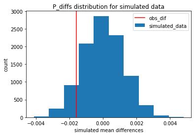

```python
# plotting sampling distribution #
plt.hist(p_diffs)
plt.axvline(obs_dif, color='red')
plt.xlabel("simulated mean differences")
plt.ylabel("count")
plt.title("P_diffs distribution for simulated data")
plt.legend(["obs_dif", "simulated_data"])
plt.show();
```

```python
# new approach for simulating data without for loops
new_page_converted = np.random.binomial(n_new, p_new,  10000)/n_new
old_page_converted = np.random.binomial(n_old, p_old,  10000)/n_old
p_diffs = new_page_converted - old_page_converted
```

**j.** What proportion of the **p_diffs** are greater than the actual difference observed in the `df2` data?

```python
(p_diffs>obs_dif).mean()
```

```
0.9032
```

```python
np.std(p_diffs)
```

```
0.0012097114387724815
```

```python
null_vals = np.random.normal(0, np.std(p_diffs), 10000)
```

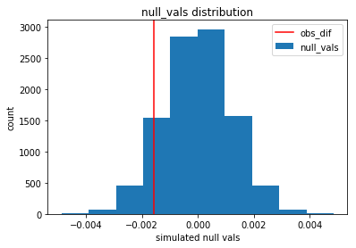

```python
# sampling null normal distribution#
plt.hist(null_vals)
plt.axvline(obs_dif, color='red')
plt.xlabel("simulated null vals")
plt.ylabel("count")
plt.title("null_vals distribution")
plt.legend(["obs_dif", "null_vals"]);
```

```python
(null_vals>obs_dif).mean()
```

```
0.90569999999999995
```

### p_value of observed difference in propotions bet. new_page and old_page is larger than 0.05 so it is not significantly different so we cannot reject null hypothesis.

```python
import statsmodels.api as sm

# number of conversions with the old_page
convert_old = df2_control['converted'].value_counts()[1]
print(convert_old)
# number of conversions with the new_page
convert_new = df2_treatment['converted'].value_counts()[1]
print(convert_new)
# number of individuals who were shown the old_page
n_old = df2_control.shape[0]
print(n_old)
# number of individuals who received new_page
n_new = df2_treatment.shape[0]
print(n_new)
```

```
17489
17264
145274
145311
```

```python
import statsmodels.api as sm
# ToDo: Complete the sm.stats.proportions_ztest() method arguments
z_score, p_value = sm.stats.proportions_ztest([convert_new,convert_old],[n_new,n_old],alternative='larger')
print(z_score, p_value)
```

```
-1.31160753391 0.905173705141
```

# logistic regression

```python
df2['intercept'] = 1
df2[['ab_page','old_page']] = pd.get_dummies(df2['landing_page'])
df2.head()
```

|  | user_id | timestamp | group | landing_page | converted | intercept | ab_page | old_page |
| --- | --- | --- | --- | --- | --- | --- | --- | --- |
| 0 | 851104.0 | 2017-01-21 22:11:48.556739 | control | old_page | 0 | 1 | 0 | 1 |
| 1 | 804228.0 | 2017-01-12 08:01:45.159739 | control | old_page | 0 | 1 | 0 | 1 |
| 2 | 661590.0 | 2017-01-11 16:55:06.154213 | treatment | new_page | 0 | 1 | 1 | 0 |
| 3 | 853541.0 | 2017-01-08 18:28:03.143765 | treatment | new_page | 0 | 1 | 1 | 0 |
| 4 | 864975.0 | 2017-01-21 01:52:26.210827 | control | old_page | 1 | 1 | 0 | 1 |

**c.** Use **statsmodels** to instantiate your regression model on the two columns you created in part (b). above, then fit the model to predict whether or not an individual converts.

```python
model = sm.Logit(df2['converted'], df2[['intercept', 'ab_page']])
results = model.fit()
```

```
Optimization terminated successfully.
         Current function value: 0.366118
         Iterations 6
```

**d.** Provide the summary of your model below, and use it as necessary to answer the following questions.

```python
results.summary2()
```

| Model: | Logit | No. Iterations: | 6.0000 |
| --- | --- | --- | --- |
| Dependent Variable: | converted | Pseudo R-squared: | 0.000 |
| Date: | 2022-03-19 07:45 | AIC: | 212780.6032 |
| No. Observations: | 290585 | BIC: | 212801.7625 |
| Df Model: | 1 | Log-Likelihood: | -1.0639e+05 |
| Df Residuals: | 290583 | LL-Null: | -1.0639e+05 |
| Converged: | 1.0000 | Scale: | 1.0000 |

|  | Coef. | Std.Err. | z | P>\|z\| | [0.025 | 0.975] |
| --- | --- | --- | --- | --- | --- | --- |
| intercept | -1.9888 | 0.0081 | -246.6690 | 0.0000 | -2.0046 | -1.9730 |
| ab_page | -0.0150 | 0.0114 | -1.3116 | 0.1897 | -0.0374 | 0.0074 |

## p_value at ab_page = 0.1897 which differs at part I & part II because here h1:p_new - p_old > 0 so it is one tailed while at part III p_new-p_old !=0 ... so the p_value get changed.

**f.** Now, you are considering other things th t might influence whether or not an individual converts. Discuss why it is a good idea to consider other factors to add into your regression model. Are there any disadvantages to adding additional terms into your regression model?

### country or age or gender or economic status or educational level but take care if there is any conditions you add if they are dependent on each other or it will give wrong results.

```python
# Read the countries.csv
df_countries = pd.read_csv('countries.csv')
```

```python
# Join with the df2 dataframe
df_merged = df2.merge(df_countries,on='user_id',how='inner')
df_merged.head()
```

|  | user_id | timestamp | group | landing_page | converted | intercept | ab_page | old_page | country |
| --- | --- | --- | --- | --- | --- | --- | --- | --- | --- |
| 0 | 851104.0 | 2017-01-21 22:11:48.556739 | control | old_page | 0 | 1 | 0 | 1 | US |
| 1 | 804228.0 | 2017-01-12 08:01:45.159739 | control | old_page | 0 | 1 | 0 | 1 | US |
| 2 | 661590.0 | 2017-01-11 16:55:06.154213 | treatment | new_page | 0 | 1 | 1 | 0 | US |
| 3 | 853541.0 | 2017-01-08 18:28:03.143765 | treatment | new_page | 0 | 1 | 1 | 0 | US |
| 4 | 864975.0 | 2017-01-21 01:52:26.210827 | control | old_page | 1 | 1 | 0 | 1 | US |

```python
df_merged[['CA','UK','US']] = pd.get_dummies(df_merged['country'])
df_merged.head()
```

|  | user_id | timestamp | group | landing_page | converted | intercept | ab_page | old_page | country | CA | UK | US |
| --- | --- | --- | --- | --- | --- | --- | --- | --- | --- | --- | --- | --- |
| 0 | 851104.0 | 2017-01-21 22:11:48.556739 | control | old_page | 0 | 1 | 0 | 1 | US | 0 | 0 | 1 |
| 1 | 804228.0 | 2017-01-12 08:01:45.159739 | control | old_page | 0 | 1 | 0 | 1 | US | 0 | 0 | 1 |
| 2 | 661590.0 | 2017-01-11 16:55:06.154213 | treatment | new_page | 0 | 1 | 1 | 0 | US | 0 | 0 | 1 |
| 3 | 853541.0 | 2017-01-08 18:28:03.143765 | treatment | new_page | 0 | 1 | 1 | 0 | US | 0 | 0 | 1 |
| 4 | 864975.0 | 2017-01-21 01:52:26.210827 | control | old_page | 1 | 1 | 0 | 1 | US | 0 | 0 | 1 |

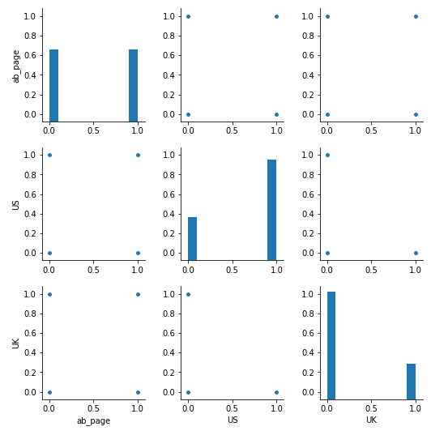

```python
import seaborn as sb
sb.pairplot(df_merged[['ab_page','US','UK']]);
```

### it seems that there is no multicollinearity between x-variables .

```python
# Fit your model, and summarize the results
df_merged['intercept'] = 1
df_merged['US_ab']=df_merged['US']*df_merged['ab_page']
df_merged['UK_ab']=df_merged['UK']*df_merged['ab_page']
model2 = sm.Logit(df_merged['converted'], df_merged[['intercept', 'ab_page','US','UK','US_ab','UK_ab']])
results = model2.fit()
results.summary2()
```

```
Optimization terminated successfully.
         Current function value: 0.366109
         Iterations 6
```

| Model: | Logit | No. Iterations: | 6.0000 |
| --- | --- | --- | --- |
| Dependent Variable: | converted | Pseudo R-squared: | 0.000 |
| Date: | 2022-03-19 07:45 | AIC: | 212782.6602 |
| No. Observations: | 290584 | BIC: | 212846.1381 |
| Df Model: | 5 | Log-Likelihood: | -1.0639e+05 |
| Df Residuals: | 290578 | LL-Null: | -1.0639e+05 |
| Converged: | 1.0000 | Scale: | 1.0000 |

|  | Coef. | Std.Err. | z | P>\|z\| | [0.025 | 0.975] |
| --- | --- | --- | --- | --- | --- | --- |
| intercept | -2.0040 | 0.0364 | -55.0077 | 0.0000 | -2.0754 | -1.9326 |
| ab_page | -0.0674 | 0.0520 | -1.2967 | 0.1947 | -0.1694 | 0.0345 |
| US | 0.0175 | 0.0377 | 0.4652 | 0.6418 | -0.0563 | 0.0914 |
| UK | 0.0118 | 0.0398 | 0.2957 | 0.7674 | -0.0663 | 0.0899 |
| US_ab | 0.0469 | 0.0538 | 0.8718 | 0.3833 | -0.0585 | 0.1523 |
| UK_ab | 0.0783 | 0.0568 | 1.3783 | 0.1681 | -0.0330 | 0.1896 |

```python
from subprocess import call
call(['python', '-m', 'nbconvert', 'Analyze_ab_test_results_notebook.ipynb'])
```

```
0
```